# Predicting and Analyzing U.S. Flight Delays: Identifying Key Factors and Improving Forecast Accuracy

2024-10-28

# EDA

## 1. Loading the Data

```r
flight <- data.frame(read.csv("Flight_delay.csv"))
```

Dataset loaded..

```r
column_names <- c('Day_of_Week','Date','Departure_Time','Arrival_Time','Scheduled_Arrival_Time',  'Unique_Carrier_Code','Carrier_name', 'Flight_Number','Tail_Number', 'Actual_Elapsed_Time_min','Estimated_Elapsed_Time_min','Air_Time_min', 'Arrival_Delay_min', 'Departure_Delay_min','Origin', 'Origin_Airport','Destination','Destination_Airport', 'Distance_mi','Taxi_In_min','Taxi_Out_min', 'Cancelled', 'CancellationCode','Diverted','Carrier_Delay_min','Weather_Delay_min', 'NAS_Delay_min','Security_Delay_min','Late_Aircraft_Delay_min')

colnames(flight) <- column_names
unique_carriers <- data.frame(unique(flight[,7]))
```

## 2. Description:

Number of rows before Data pre-processing: 484551

Unique Airlines:

| unique.flight…7.. |
| --- |
| Southwest Airlines Co. |
| Skywest Airlines Inc. |
| United Air Lines Inc. |
| US Airways Inc. |
| Delta Air Lines Inc. |
| Atlantic Southeast Airlines |
| Frontier Airlines Inc. |
| Hawaiian Airlines Inc. |
| American Eagle Airlines Inc. |
| American Airlines Inc. |
| Alaska Airlines Inc. |
| JetBlue Airways |

Reasons for the delay:

1. CarrierDelay → Flight delay due to carrier(e.g. maintenance or crew problems, aircraft cleaning, fueling, etc), 0 = No, yes = (in minutes)
2. WeatherDelay → Flight delay due to weather, 0 = No, yes = (in minutes)
3. NASDelay → Flight delay by NSA(National Aviation System), 0 = No, yes = (in minutes)
4. SecurityDelay → Flight delay by security reason, 0 = No, yes = (in minutes)
5. LateAircraftDelay → Flight delay by Aircraft reason, 0 = No, yes = (in minutes)

## 3. Data Preprocessing:

### 3.1. Outliers:

Removing outliers and null rows with a threshold of 1.5

```r
remove_outliers <- function(df, columns) {
    df_clean <- df

    for(column_name in columns) {
        # Get the specified column
        x <- df_clean[[column_name]]

        # Removing NA values
        valid_rows <- !is.na(x)
        x_clean <- x[valid_rows]

        # Calculating Q1, Q3, and IQR
        Q1 <- quantile(x_clean, 0.25)
        Q3 <- quantile(x_clean, 0.75)
        IQR <- Q3 - Q1

        # bounds for outlier removal
        lower_bound <- Q1 - 1.5 * IQR
        upper_bound <- Q3 + 1.5 * IQR

        # summary before removal
        cat("\nProcessing", column_name, ":\n")
        cat("Original rows:", sum(valid_rows), "\n")
        cat("Q1:", Q1, "Q3:", Q3, "IQR:", IQR, "\n")
        cat("Lower bound:", lower_bound, "Upper bound:", upper_bound, "\n")

        # Deleting outlier rows
        keep_rows <- x >= lower_bound & x <= upper_bound & valid_rows
        df_clean <- df_clean[keep_rows, ]

        # summary after removal
        cat("Rows after removal:", nrow(df_clean), "\n")
        cat("Outliers removed:", sum(valid_rows) - nrow(df_clean), "\n\n")
    }

    return(df_clean)
}
```

```r
library(ggplot2)
flight_b <- remove_outliers(flight,c('Arrival_Delay_min','Carrier_Delay_min','Weather_Delay_min','NAS_Delay_min','Security_Delay_min','Late_Aircraft_Delay_min'))
```

[output not shown]

Number of rows after nulls and Outlier removal: 325403

### 3.2. Normality checks:

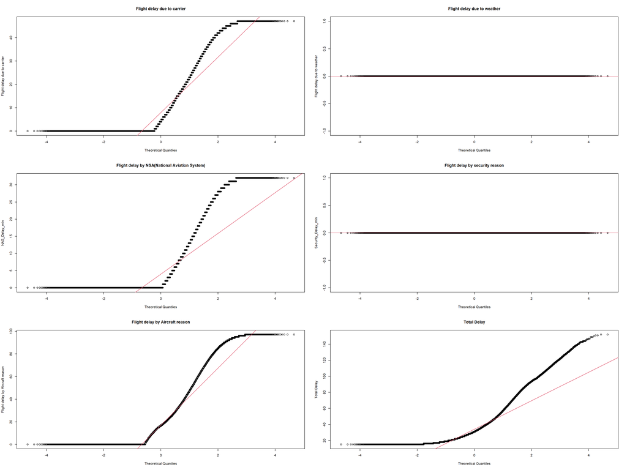

```r
par(mfrow = c(3, 2))
qqnorm(flight_b$Carrier_Delay_min, ylab = 'Flight delay due to carrier', main = "Flight delay due to carrier"); qqline(flight_b$Carrier_Delay_min,col=2)
qqnorm(flight_b$Weather_Delay_min, ylab = 'Flight delay due to weather', main = "Flight delay due to weather"); qqline(flight_b$Weather_Delay_min,col=2)
qqnorm(flight_b$NAS_Delay_min, ylab = 'NAS_Delay_min', main = "Flight delay by NSA(National Aviation System)"); qqline(flight_b$NAS_Delay_min,col=2)
qqnorm(flight_b$Security_Delay_min, ylab = 'Security_Delay_min', main = "Flight delay by security reason"); qqline(flight_b$Security_Delay_min,col=2)
qqnorm(flight_b$Late_Aircraft_Delay_min, ylab = 'Flight delay by Aircraft reason', main = "Flight delay by Aircraft reason"); qqline(flight_b$Late_Aircraft_Delay_min,col=2)
qqnorm(flight_b$Arrival_Delay_min, ylab = 'Total Delay' , main = "Total Delay"); qqline(flight_b$Arrival_Delay_min,col=2)
```

weather and security delays are rare in this dataset and when they occur, they’re likely significant outliers.

None of the delay types follow a normal distribution.

Since these distributions are not normal, Parametric statistical studies cannot be performed.

## 4. SMART Question and Analysis:

“For top 5 most delayed airlines, can we identify major reasons and its trend over 6 months, so that it can help airlines to relocate proper resources and improve its operational efficiencies”

### 4.1. Identifying top 5 airlines:

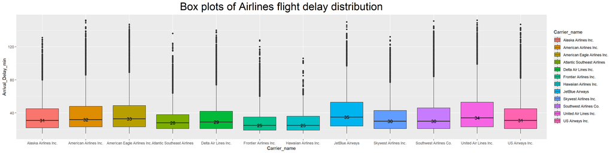

```r
ggplot(flight_b,aes(Carrier_name,Arrival_Delay_min))+geom_boxplot(aes(fill = Carrier_name ))+labs(title = "Box plots of Airlines flight delay distribution") + theme(plot.title = element_text(size = 25,hjust =0.5)) + stat_summary(aes(y = Arrival_Delay_min , label = round(..y.., 2)),
                 fun.y = median, geom = "text")
```

From the box-plots above, higher median lines are found for:

JetBlue Airways

United Air Lines Inc.

American Eagle Airlines Inc.

American Airlines Inc.

US Airways Inc.

```r
flight_5 <- flight_b[flight_b$Carrier_name %in% c('JetBlue Airways','United Air Lines Inc.','US Airways Inc.','American Airlines Inc.','American Eagle Airlines Inc.'),]
```

### 4.2. Identifying major reasons for these 5 airlines:

```r
library(ggplot2)
library(reshape2)
avg_delays <- aggregate(
  cbind(
    Carrier_Delay_min,
    Weather_Delay_min,
    NAS_Delay_min,
    Security_Delay_min,
    Late_Aircraft_Delay_min
  ) ~ Carrier_name,
  data = flight_5,
  FUN = mean,
  na.rm = TRUE
)

delay_long <- melt(
  avg_delays,
  id.vars = "Carrier_name"
)

delay_long <- melt(avg_delays, id.vars = "Carrier_name")
delay_totals <- aggregate(value ~ Carrier_name, data = delay_long, sum)
delay_long <- merge(delay_long, delay_totals, by = "Carrier_name",
                   suffixes = c("", "_total"))
delay_long$percentage <- (delay_long$value / delay_long$value_total)*100

threshold <- 0
delay_long$label <- ifelse(delay_long$percentage >  threshold, sprintf("%.1f%%",delay_long$percentage),"")
```

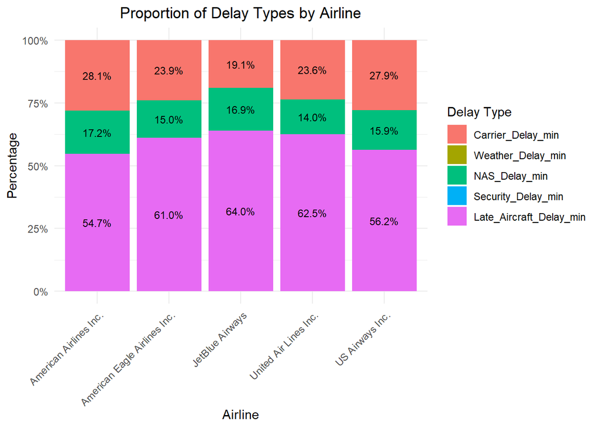

```r
ggplot(delay_long, aes(x = Carrier_name, y = value, fill = variable)) +
  geom_bar(stat = "identity", position = "fill") +
  geom_text(aes(label = label),
            position = position_fill(vjust = 0.5),size = 3)+
  theme_minimal() +
  labs(
    title = "Proportion of Delay Types by Airline",
    x = "Airline",
    y = "Percentage",
    fill = "Delay Type"
  ) +
  theme(
    axis.text.x = element_text(angle = 45, hjust = 1),
    plot.title = element_text(hjust = 0.5)
  ) +
  scale_y_continuous(labels = scales::percent)
```

```r
flight_5$MonthYear <- format(as.Date(flight_5$Date, "%d-%m-%Y"), "%b-%Y")

# Calculate monthly averages for each airline and delay type
monthly_delays <- aggregate(
  cbind(
    Carrier_Delay_min,
    Weather_Delay_min,
    NAS_Delay_min,
    Security_Delay_min,
    Late_Aircraft_Delay_min
  ) ~ MonthYear + Carrier_name,
  data = flight_5,
  FUN = mean,
 na.rm = TRUE
)
```

```r
delay_long <- melt(monthly_delays,
                  id.vars = c("MonthYear", "Carrier_name"),
                  variable.name = "Delay_Type",
                  value.name="Minutes")
```

Analysis from above graph:

1. Late Aircraft Delay dominates across all airlines, accounting for the largest proportion of delays, highest being in JetBlue Airways (64.0%).
2. Followed by Carrier Delay and NAS Delay, all three combined causes 100% delays.
3. Weather and Security delays appear minimal or non-existent
4. Late aircraft delays being dominant suggests a huge impact in airline operations
5. Different airlines might need different strategies based on their delay profiles, for example JetBlue might focus on late aircraft issues, while American Airlines might prioritize carrier-related delays since American Airlines has the highest percentage compared to others.

### 4.3. Identifying major reasons for these 5 airlines:

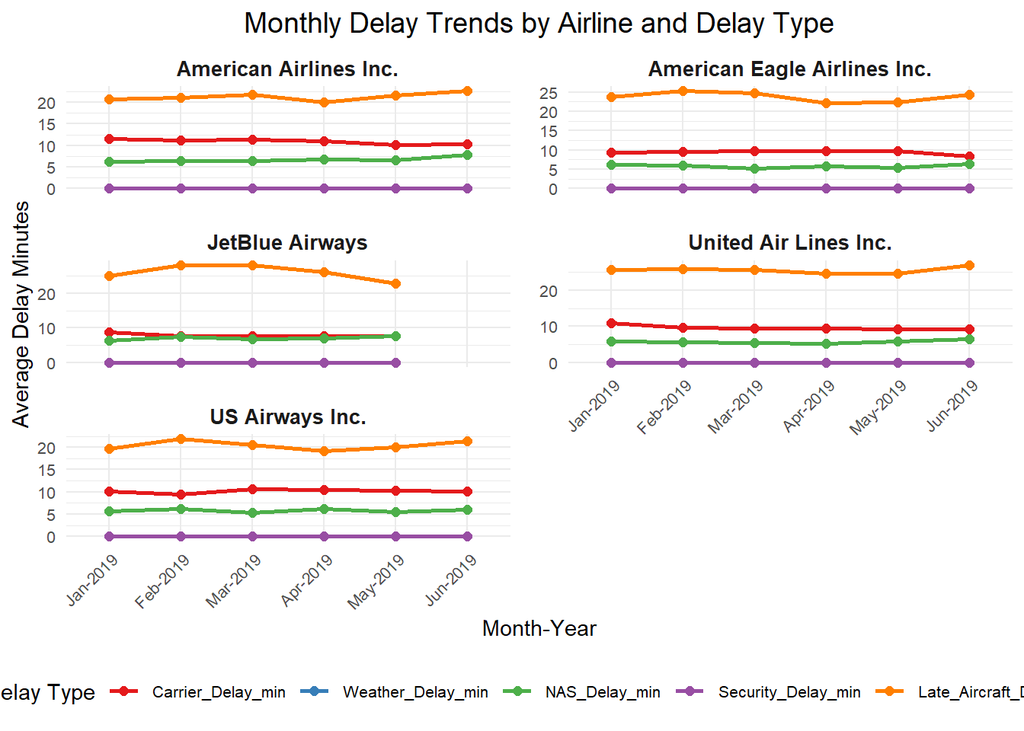

```r
library(dplyr)

delay_long <- delay_long %>%
  mutate(
    MonthDate = as.Date(paste0("01-", MonthYear), format = "%d-%b-%Y"),
    MonthYear = factor(format(MonthDate, "%b-%Y"),levels = format(sort(unique(MonthDate)),"%b-%Y")))
ggplot(delay_long,
       aes(x = MonthYear,
           y = Minutes,
           color = Delay_Type,
           group = Delay_Type)) +
  geom_line(linewidth = 1) +
  geom_point(size = 2) +
  facet_wrap(~Carrier_name, ncol = 2, scales = "free_y") +
  theme_minimal() +
  labs(
    title = "Monthly Delay Trends by Airline and Delay Type",
    x = "Month-Year",
    y = "Average Delay Minutes",
    color = "Delay Type"
  ) +
  theme(
    axis.text.x = element_text(angle = 45, hjust = 1, size = 8),
    axis.text.y = element_text(size = 8),
    strip.text = element_text(size = 10, face = "bold"),
    plot.title = element_text(size = 14, hjust = 0.5),
    legend.position = "bottom",
    legend.text = element_text(size = 8),
    panel.spacing = unit(1, "lines")
  ) +
  scale_color_brewer(palette = "Set1") +
  guides(color = guide_legend(nrow=1))
```

Consistency of analysis over 6 month period:

1. Late Aircraft Delays (orange line) consistently show the highest delays across all airlines
2. Security Delays (purple line) consistently show the lowest delays
3. Most trends remain relatively stable across the 6-month period